# Aufgabe 06

Christoph Gastmann | Matrikel: 8112863

2024-08-01

# laden der Pakete

```r
library(car)
```

```r
library(ggplot2)
library(tidyverse)
```

1. Lesen Sie mit scan Gewichtsdaten in R ein und kontrollieren Sie Struktur der eingelesenen Daten!

```r
data_wolle <- scan("Wollknaeuelgewichte2024.txt", sep = " ")
data_wolle
```

```
##  [1] 49.64087 49.72384 49.86753 49.90811 49.91327 49.91386 49.92428 50.01647
##  [9] 50.17634 50.17872 50.21931 50.22145 50.23374 50.28818 50.31916 50.45590
## [17] 50.89876 51.06851 51.15862 51.46734
```

```r
head(data_wolle, 5)
```

```
## [1] 49.64087 49.72384 49.86753 49.90811 49.91327
```

```r
tail(data_wolle, 5)
```

```
## [1] 50.45590 50.89876 51.06851 51.15862 51.46734
```

2. Der Hersteller der Wickelmaschine hat angegeben, dass die Wickelgewichte normalverteilt seien. ¨Uberpr¨ufen Sie diese Aussage mit einem geeigneten explorativen Werkzeug! Was halten Sie von der Aussage?

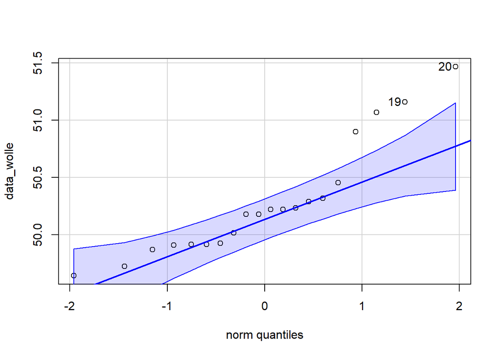

```
## [1] 20 19
```

```r
qqPlot(data_wolle)
```

Ich würde dem hersteller widersprechen. Da die Gewichte systematisch von der Normalverteilung abweichen. Wie im QQ-Plot zu sehen, liegen die empirischen Gewichte tendenziell über den zu erwartenden Gewichten. Insbesondere für besonders schwere Wollknäule (>50.75g) ist das der Fall.

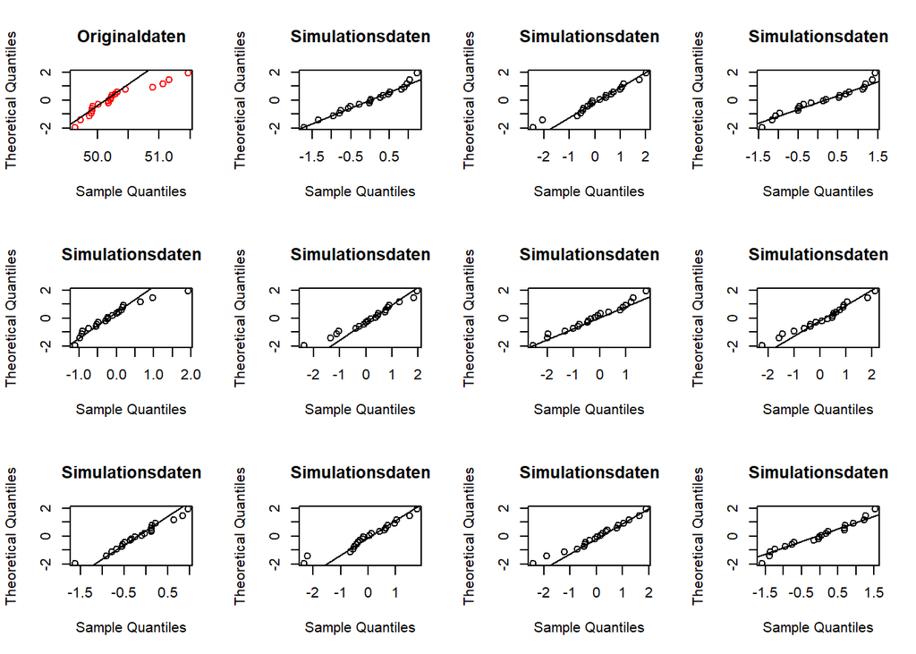

```r
qqnorm.sim <- function(x) {
  oldp <- par(mfrow = c(3, 4))   # oldp speichert die aktuellen
    # Einstellungen des Grafiklayouts (bevor der (3x4)-Mehr-
    # fachplotrahmen aktiviert wird), um sie nachher wiederher-
    # zustellen.

   qqnorm(x, main = "Originaldaten",  # Normal-QQ-Plot der zu
          datax = TRUE, col = "red")  # beurteilenden Daten
   qqline(x, datax = TRUE)            # (rot) mit Refenzlinie.

   n <- length(x)   # Stichprobenumfang der zu beurteil. Daten.
   replicate(11, {  # 11-fache Wiederh. der Befehle in {....}.
         xx <- rnorm(n)  # Erzeugung normalverteilter Daten.
         qqnorm(xx, main = "Simulationsdaten", datax = TRUE)
         qqline(xx, datax = TRUE)
         } )
 invisible(par(oldp))  # Restauration des vorherigen Grafik-
                       # layouts, ohne dass ein Rückgabewert
                       # an der Aufrufstelle ausgegeben wird.
 # Alternative: on.exit(par(oldp)) # Bedeutung siehe Hifeseite!
}

qqnorm.sim(data_wolle)
```

Ich habe mich noch ihrer `qqnorm.sim` bedient. Hier sind die vergleiche mehrdeutig. Es kommt schon mal vor, dass bei den simulierten Daten zu ähnlichen ausreißern kommt, wie in den emp. Daten.

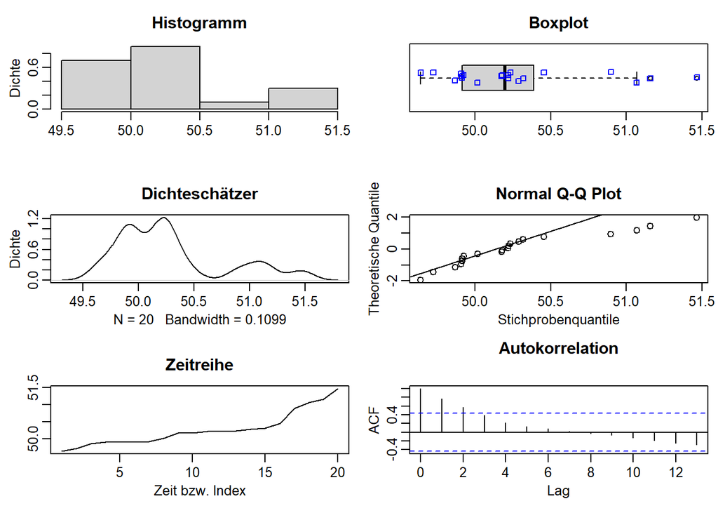

```
##     Min.  1st Qu.   Median     Mean  3rd Qu.     Max.  St.Dev.
## 49.64087 49.91371 50.19902 50.27971 50.35334 51.46734  0.49950
```

```r
eda <- function(x) {
 oldp <- par(mfrow = c(3, 2), mgp = c(1.7, 0.6,0),
             mar = c(3.5, 3, 2.6, 0.5) + 0.1, cex = 0.8)
 on.exit(par(oldp))

 hist(x, freq = FALSE, ylab = "Dichte", xlab = "",
      main = "Histogramm")
 boxplot(x, horizontal = TRUE, main = "Boxplot")
 set.seed(42)
 stripchart(x, add = TRUE, col = "blue", method = "jitter")

 qa <- diff(quantile(x, c(1/4, 3/4)))
 dest <- density(x, width = qa)
 plot(dest, ylab = "Dichte", main = "Dichteschätzer")

 qqnorm(x, datax = TRUE, ylab = "Stichprobenquantile",
        xlab = "Theoretische Quantile")
 qqline(x, datax = TRUE)
 ts.plot(x, ylab = "", xlab = "Zeit bzw. Index",
         main = "Zeitreihe")

 acf(x, main = "Autokorrelation")

 d <- max(3, getOption("digits") - 3)
 c(summary(x), "St.Dev." = signif(sd(x), digits = d))
}

eda(data_wolle)
```

Weiter habe ich mich noch bei ihrer Funktion `eda` bedient. Hier erkennt man, dass die Daten nicht Symetrisch sind.

3. Es besteht der Verdacht, dass das mediane Wickelgewicht des Produktionsprozesses vom gew¨unschten Sollgewicht abweicht. Es ist Ihre Aufgabe, datenanalytisch zu untersuchen, ob dieser Verdacht gerechtfertigt ist. W¨ahlen und nennen Sie ein dazu geeignetes statistisches Verfahren und seine Voraussetzungen! Sind die Voraussetzungen f¨ur die vorliegenden Daten erf¨ullt bzw. ¨uberhaupt ¨uberpr¨ufbar?

Sofern die Daten nicht als normalverteilt gelten, ist der nonparametrische Pendant zum t-Test der Wilcoxon-Vorzeichen-Rang-Test. Dafür müssen die Daten wenigstens ordinalverteilt sein, was bei Gewichtangaben in Gramm definitiv gegeben ist.

4. Formalisieren Sie die beiden Aussagen, zwischen denen in dem von Ihnen in Teil c gew¨ahlten Verfahren zu entscheiden ist, und benennen Sie sie unter Verwendung der ¨ublichen Fachausdr¨ucke! Legen Sie sodann denWert einer entscheidenden Gr¨oße fest und benennen Sie auch sie mit dem ¨ublichen Fachausdruck! Wie lautet die zugeh¨orige Entscheidungsregel?

Edit*: Man könnte auch argumentiren, dass ein einseitiger Test gerechnet werden kann. Da wäre aber die Frage, was die Hypothese wäre. Als Geschäftsmann wäre es wichtig, dass die Abweichung nicht zu weit nach oben geht, damit ich nicht zu viel Geld verliere. Als Käufer wäre es wichtig, dass die Abweichung nicht nach Unten geht, damit auch nicht für zu wenig Wolle als eigentlich angedacht ist bezahle. Da es nicht ersichtlich ist, wird beiseitig gerechnet.

5. F¨uhren Sie schließlich die Datenanalyse durch und teilen Sie Ihre Entscheidung mit!

```r
Test_Statistik <-  wilcox.test(data_wolle, mu = 50)
```

```r
hypothesen_test <- function(p_wert, alpha = 0.05) {

  if (p_wert <= alpha) {
    message("Die $H_0$ muss verworfen werden und die $H_1$ kann angenommen werden")
  } else {
    message("Die $H_0$ kann nicht verworfen werden und die $H_1$ muss verworfen werden")
  }
}

Antwort <- hypothesen_test(Test_Statistik$p.value)
```

```
## Die $H_0$ muss verworfen werden und die $H_1$ kann angenommen werden
```

```r
median(data_wolle)
```

```
## [1] 50.19902
```

Die H0 wird zu Gunsten der Alternaitvhypothese H1 verworfen, die Wollknäule sind also im Mittel signifikant schwerer als die angegebenen 50 g 50.199015